# A systematic review and meta-analysis of pro-dopaminergic interventions for anhedonia - results from human studies

Jaycee Kennett, Claire Friedrich, Edoardo G. Ostinelli

2024-03-25

## Description of the methodological approach

1. In this first iteration of the living systematic review we searched for randomised controlled trials that compared pro-dopaminergic interventions to placebo in adults with unipolar depression (i.e. any standardised measure, above-threshold symptoms on any standardised measure, or a clinical diagnosis based on any operationalised criteria).
2. Eight databases were searched from inception up to the 4th of September, 2023 (see appendix for the full search strategies). Database search results were imported into [EPPI-Reviewer](https://eppi.ioe.ac.uk/cms/Default.aspx?tabid=2914) and de-duplicated prior to screening. All steps related to record screening and data extraction were completed in [EPPI-Reviewer](https://eppi.ioe.ac.uk/cms/Default.aspx?tabid=2914).
3. Titles and abstracts of the identified records were screened by at least two reviewers (CF, MC, JK, JP). We retrieved the full-texts and any supporting documents for all records that were not excluded at the title and abstract screening stage. The full-text screening was conducted by at least two reviewers (CF, JK, JP, AK, EB). Conflicts at title and abstract, and full-text screening, were resolved through discussion between the two reviewers and involvement of a third reviewer (AC, EGO). Additional information on the full study eligibility criteria can be found in the pre-published [protocol](https://wellcomeopenresearch.org/articles/8-425).
4. Relevant data was extracted using [EPPI-Reviewer](https://eppi.ioe.ac.uk/cms/Default.aspx?tabid=2914) by at least two reviewers (CF, CA, EB, JK).
5. As specified in our [protocol](https://wellcomeopenresearch.org/articles/8-425), we focused on:
- anhedonia symptom severity: using anhedonia-specific scales, anhedonia-specific sub-scales, or individual items focusing on anhedonia (observer-rated or self-rated). Continuous, primary outcome.
- acceptability: proportion of drop outs for any reason. Binary, secondary outcome.
- tolerability: the proportion of drop outs due to any adverse event. Binary, secondary outcome.
- safety: the proportion of specific adverse events. Binary, secondary outcome.
- anxiety symptom severity: as per observer or self-reported standardised scales. Continuous, secondary outcome.

For anhedonia and anxiety symptom severity, we extracted outcome data reported at 8 weeks post-treatment or manipulation. If information at 8 weeks was not available, we considered eligible data ranging between 4 and 12 weeks (with preference to the time point closest to 8 weeks, and if equidistant the longer outcome). For acceptability, tolerability, safety and specific-adverse events, we extracted outcome data reported at the end of the studies.

Please see the final manuscript, extended data, and [protocol](https://wellcomeopenresearch.org/articles/8-425) for more details.

# Results

Below are the results of the systematic review and meta-analysis including a PRISMA flow diagram (Page et al 2021) for details of the flow of study selection, a table of characteristics for included studies, risk of bias assessment, forest plots for each outcome with accompanying descriptive text.

### [PRISMA diagram]

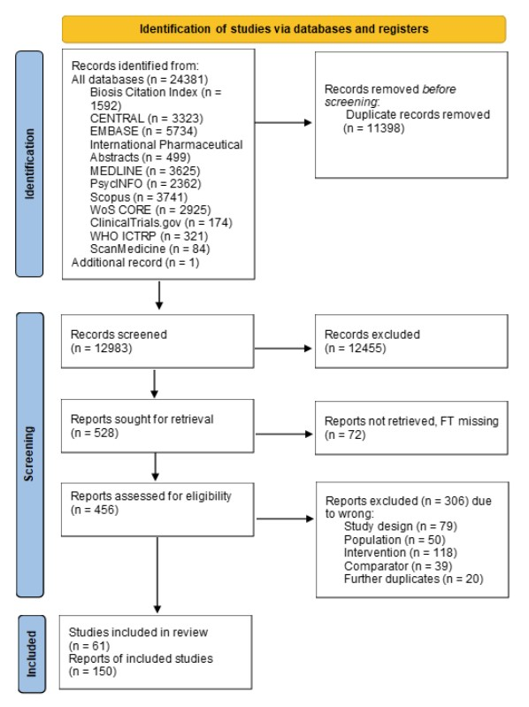

## Description of included studies

We identified 61 eligible studies. The study characteristics can be found in **Table 1**. Data from studies contributed with at least one outcome with quantitative data (total of 9745 participants), which included adults from multiple countries. The mean age of participants was 42.4 years (range 15 to 72 years), with a mean proportion of 0.58 female participants (range 0 to 0.86). Included studies allocated the participants to treatment lasting between 4 to 12.9 weeks (median, 6 weeks).

Author (Year)

Country

Sponsor

Arms (in LSR)

Setting

Condition

Treatment duration

Intervention group

Participants (n)

Females (n)

Age (mean)

Age (SD) or range (specified)

Dosage fixed or flexible

Intervention format

Planned dosage range (min-max mg/day)

Delivered dosage range (min-max mg/day)

Delivered dosage (mean mg/day)

Anhedonia measure

Baseline n

Baseline anhedonia (mean (SD))

Follow-up n

Follow-up anhedonia (mean (SD))

Bymaster (2011)

Romania, Serbia, USA

DOV Pharmaceuticals, Euthymics Bioscience

2

Secondary/Tertiary Care

Depressive disorder

6 weeks

Placebo

29

19

49.5

6.9

Fixed

Oral

MADRS Anhedonia Factor

28

13.7 (1.6)

26

9.3 (1.58)

.

.

.

.

.

.

.

Amitifadine

34

25

48.2

9.4

Fixed

Oral

50mg to 50mg

25mg to 50mg

MADRS Anhedonia Factor

33

12.8 (2.1)

33

Hewett (2009)

Austria, Belgium, Bulgaria, Croatia, Estonia, Finland, Greece, Ireland, Latvia, Netherlands, Poland, Portugal, Russia, Slovakia, Spain, Sweden and Mexico

GSK

2

NA

Major depressive disorder

8 weeks

Placebo

199

142

41.8

11.56

Flexible

Oral

MEI Total

197

26.4 (12.79)

197

17.4 (19.37)

.

.

.

.

.

.

.

Bupropion XR

188

138

41.8

11.68

Flexible

Oral

150mg to 300mg

NA

170.1mg

MEI Total

187

26.8 (12.95)

187

24.6 (19.69)

Hewett (2010a)

Australia, France, Germany, the Netherlands, Norway, South Africa and Sweden

GSK

2

NA

Major depressive disorder

8 weeks

Placebo

189

125

44.5

10.79

Flexible

Oral

MEI Total

186

25.3 (12.81)

186

18.3 (21.95)

NA

NA

NA

NA

NA

NA

NA

Bupropion XR

204

127

45.6

11.76

Flexible

Oral

150mg to 300mg

150mg to 300mg

180mg

MEI Total

202

27.2 (13.5)

202

20.8 (21.74)

Hewett (2010b)

Australia, Belgium, Canada, Croatia, Finland, France, Germany, India, Latvia, Netherlands, Norway, Poland, Republic of South Africa, Russia and United States

GSK

2

NA

Major depressive disorder

10 weeks

Placebo

207

144

71.3

5.9

Flexible

Oral

MEI Total

204

29.5 (15.16)

204

16.9 (23.42)

.

.

.

.

.

.

.

Bupropion XR

211

157

70.9

5.6

Flexible

Oral

150mg to 300mg

150mg to 300mg

MEI Total

210

29 (13.85)

210

23.6 (22.89)

Jefferson (2006)

NA

GSK

2

NA

Major depressive disorder

8 weeks

Placebo

139

96

39.8

16-69 (range)

Flexible

Oral

IDS-IVR-30 Pleasure scale

137

Change from baseline = -3.7 (4.61)

.

.

.

.

.

.

.

NA

NA

NA

NA

NA

NA

NA

NA

NA

NA

IDS-C-30 Pleasure scale

133

Change from baseline = -5.3 (4.61)

.

.

.

.

.

.

.

Bupropion XR

135

89

40.0

20-68 (range)

Flexible

Oral

150mg to 450mg

150mg to 450mg

IDS-IVR-30 Pleasure scale

133

Change from baseline = -6.7 (4.61)

.

.

.

.

.

.

.

NA

NA

NA

NA

NA

NA

NA

NA

NA

NA

IDS-C-30 Pleasure scale

133

Change from baseline = -5.5 (4.61)

Koshino (2013)

Japan, South Korea

GSK

3

NA

Major depressive disorder

10 weeks

Placebo

186

85

37.9

11.09

Fixed

Oral

MADRS item 8

186

3.7 (1.06)

186

2 (1.45)

.

.

.

.

.

.

.

Bupropion 150mg

190

92

36.0

10.42

Fixed

Oral

150mg

150mg

MADRS item 8

190

3.7 (1.16)

190

2 (1.45)

.

.

.

.

.

.

.

Bupropion 300mg

188

83

37.5

10.96

Fixed

Oral

300mg

300mg

MADRS item 8

188

3.7 (1.09)

188

2.1 (1.55)

*Table 1. characteristics of all included studies*

### Primary outcome: reduction in anhedonia scores at 8 weeks (from 4 to 12 weeks)

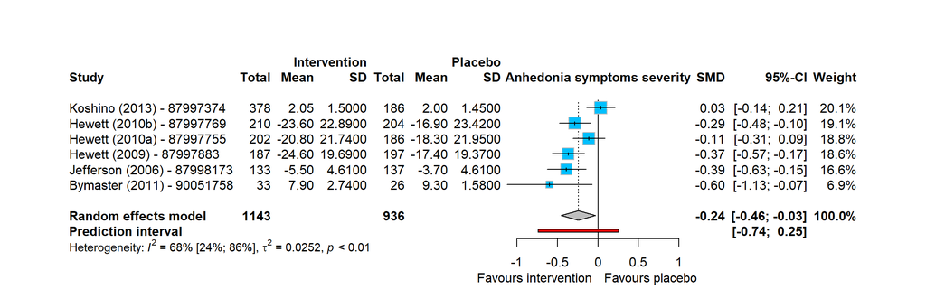

**Figure X** Forest plot for symptoms of anhedonia (primary outcome) comparing pro-dopaminergic interventions vs placebo for individuals with anhedonia at 4-12 weeks (primary timepoint). SMD: standardised mean difference, 95%CI: 95% confidence intervals, SD: standard deviation.

6 studies contributed with data to the meta-analysis with a total of 2079 participants (1143 allocated to pro-dopaminergic interventions, 936 allocated to pill placebo).

The comparative effect of pro-dopaminergic interventions versus placebo showed an effect favouring pro-dopaminergic interventions with a SMD of -0.244 (95%CI from -0.456 to -0.032). The study results presented an I2 value of 67.8% (95%CI from 23.6% to 86.4%) and a tau2 value of 0.025 (accounting for a 95% prediction interval from -0.74 to 0.252).

#### Risk of bias

Evidence for the efficacy of pro-dopaminergic interventions vs placebo in improving anhedonia was rated moderate for risk of bias. 50% of the included studies had an overall high risk of bias while the other 50% had moderate risk of bias, primarily due to missing outcome data, issues with outcome measurement, and selective reporting of findings. The extent to which the result was affected by across-study biases is unclear and all included studies were rated at least moderate in domain 5, selection of results. This result was judged to be at moderate risk of bias due to indirectness as while there was no clear indication of indirectness in terms of population, comparator, or outcomes, 80% of the studies measured the same intervention, bupropion.

#### Sub-group and meta-regression analyses

We did not find sufficient data (i.e. at least ten studies) to conduct a meta-regression for the investigated predictors. Insufficient data existed for age, proportion of females, anhedonia baseline score, anxiety baseline score, reward baseline score, and treatment duration.

### Secondary outcome: Reduction in mean anxiety score at 8 weeks (from 4 to 12 weeks)

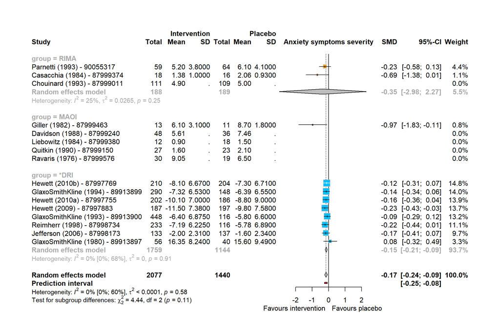

**Figure X** Forest plot for symptoms of anxiety (secondary outcome) comparing pro-dopaminergic interventions vs placebo for individuals with anxiety at 4-12 weeks (primary timepoint). SMD: standardised mean difference, 95%CI: 95% confidence intervals, SD: standard deviation.

11 studies contributed with data to the meta-analysis with a total of 3517 participants (2077 allocated to pro-dopaminergic interventions, 1440 allocated to pill placebo.

The comparative effect of pro-dopaminergic interventions versus placebo showed an effect favouring pro-dopaminergic interventions with a SMD of -0.166 (95%CI from -0.243 to -0.088). The study results presented an I2 value of 0% (95%CI from 0% to 60.2%) and a tau2 value of 0 (accounting for a 95% prediction interval from -0.251 to -0.08).

#### Sub-group and meta-regression analyses

We found enough data (i.e. at least ten studies) to conduct a meta-regression for age, proportion of females, and anxiety baseline score. Insufficient data existed for anhedonia baseline score, reward baseline score, and treatment duration.

- The meta-regression for age was not significant.
- The meta-regression for proportion of females was not significant.
- The meta-regression for anxiety baseline score was not significant.

### Secondary outcome: Dropouts due to any reason

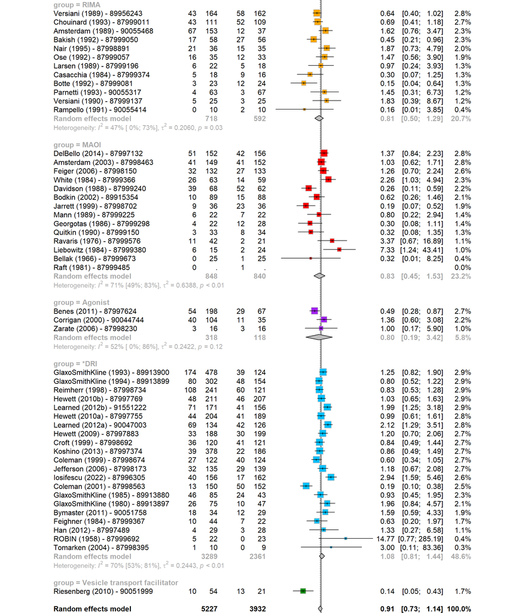

**Figure X** Forest plot for dropouts due to any reason for the comparison of pro-dopaminergic interventions vs placebo at 4-12 weeks. OR: odds ratio, 95%CI: 95% confidence intervals.

#### Sub-group and meta-regression analyses

We found enough data (i.e. at least ten studies) to conduct a meta-regression for age, proportion of females, and anxiety baseline score. Insufficient data existed for anhedonia baseline score, reward baseline score, and treatment duration.

- The meta-regression for age was not significant.
- The meta-regression for proportion of females was not significant.
- The meta-regression for anxiety baseline score was not significant.

### Secondary outcome: dropouts due to side effects

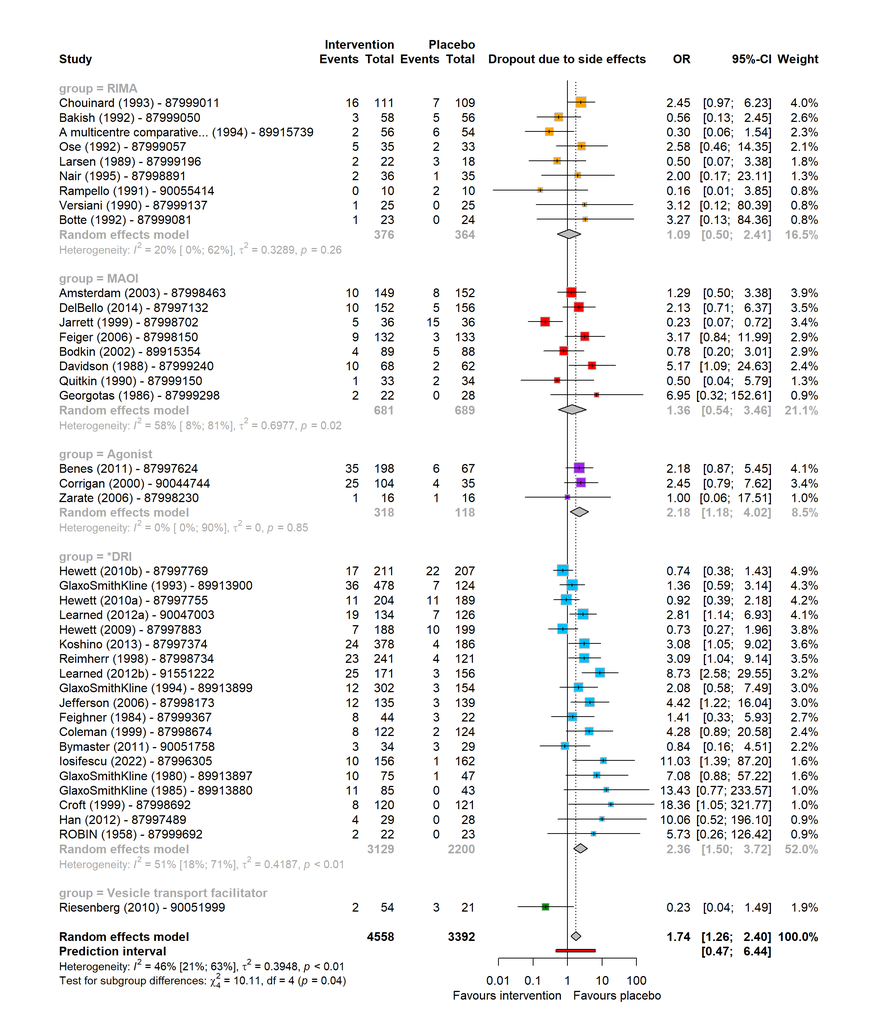

**Figure X** Forest plot for dropouts due to adverse events for the comparison of pro-dopaminergic interventions vs placebo at 4-12 weeks. OR: odds ratio, 95%CI: 95% confidence intervals.

Meta-regressions were conducted for age, sex, and baseline anxiety score. Of these, only sex was a significant predictor of dropouts due to adverse events with a beta=-2.960, SE=1.21 95%CI (-5.423; -0.497) and an R^2=40.63% and p=.022.

#### Sub-group and meta-regression analyses

We found enough data (i.e. at least ten studies) to conduct a meta-regression for age, proportion of females, and anxiety baseline score. Insufficient data existed for anhedonia baseline score, reward baseline score, and treatment duration.

- The meta-regression for age was not significant.
- The meta-regression for proportion of females was significant (beta = -2.96, 95% CI from -5.423 to -0.497).
- The meta-regression for anxiety baseline score was not significant.

### Secondary outcome: nausea

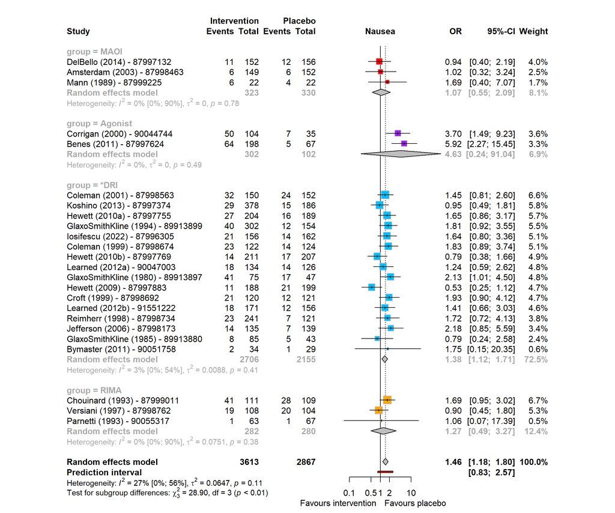

**Figure X** Forest plot for nausea for the comparison of pro-dopaminergic interventions vs placebo at 4-12 weeks. OR: odds ratio, 95%CI: 95% confidence intervals.

#### Sub-group and meta-regression analyses

We found enough data (i.e. at least ten studies) to conduct a meta-regression for age and proportion of females. Insufficient data existed for anhedonia baseline score, anxiety baseline score, reward baseline score, and treatment duration.

- The meta-regression for age was not significant.
- The meta-regression for proportion of females was not significant.

### Secondary outcome: headache

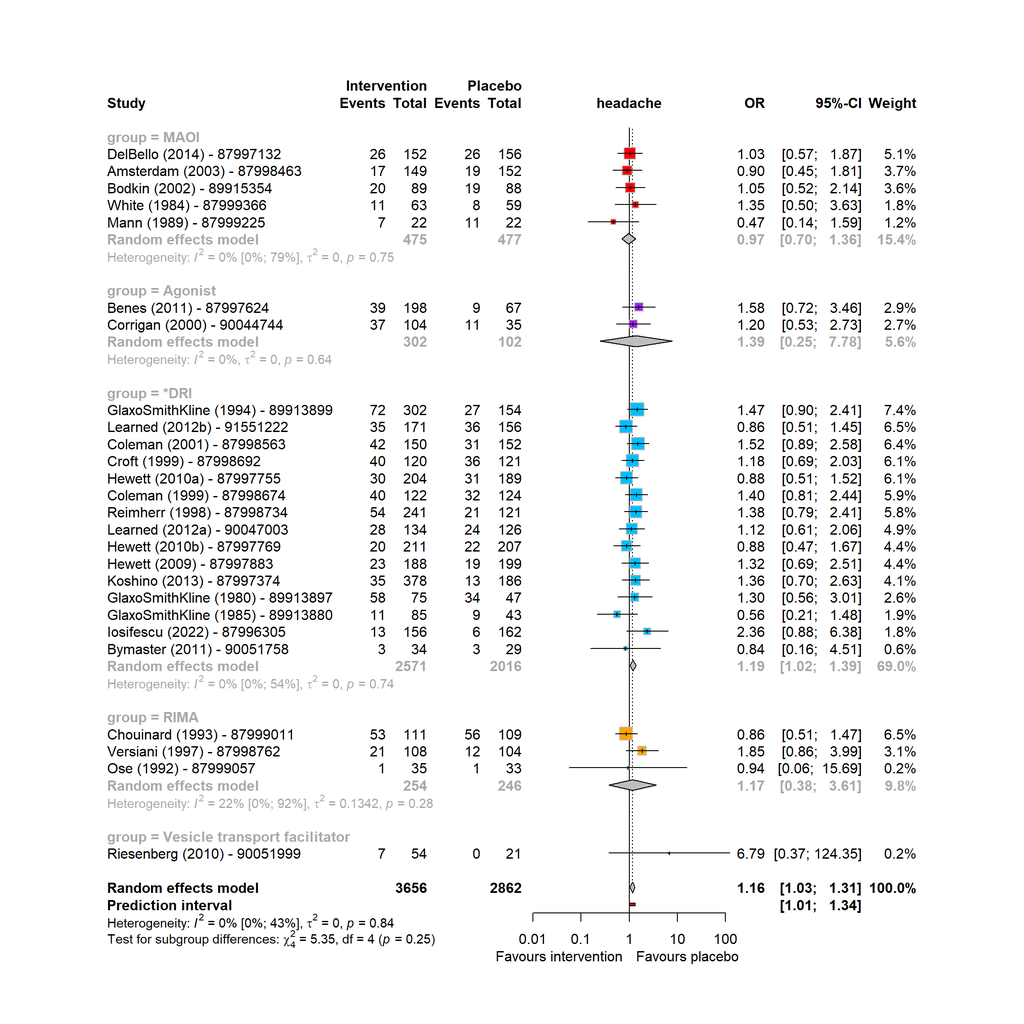

**Figure X** Forest plot for headaches for the comparison of pro-dopaminergic interventions vs placebo at 4-12 weeks. OR: odds ratio, 95%CI: 95% confidence intervals.

#### Sub-group and meta-regression analyses

We found enough data (i.e. at least ten studies) to conduct a meta-regression for age and proportion of females. Insufficient data existed for anhedonia baseline score, anxiety baseline score, reward baseline score, and treatment duration.

- The meta-regression for age was not significant.
- The meta-regression for proportion of females was not significant.

### Secondary outcome: insomnia

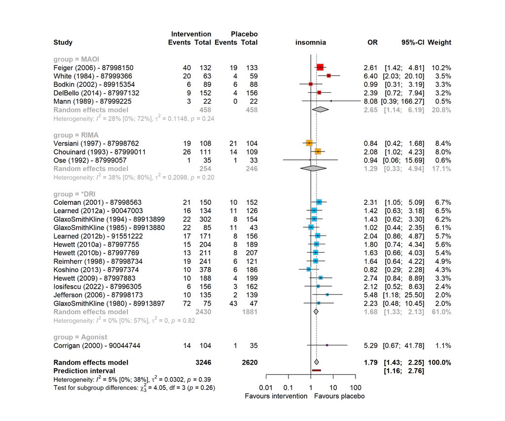

**Figure X** Forest plot for insomnia for the comparison of pro-dopaminergic interventions vs placebo at 4-12 weeks. OR: odds ratio, 95%CI: 95% confidence intervals.

#### Sub-group and meta-regression analyses

We found enough data (i.e. at least ten studies) to conduct a meta-regression for age and proportion of females. Insufficient data existed for anhedonia baseline score, anxiety baseline score, reward baseline score, and treatment duration.

- The meta-regression for age was not significant.
- The meta-regression for proportion of females was not significant.

### Secondary outcome: constipation

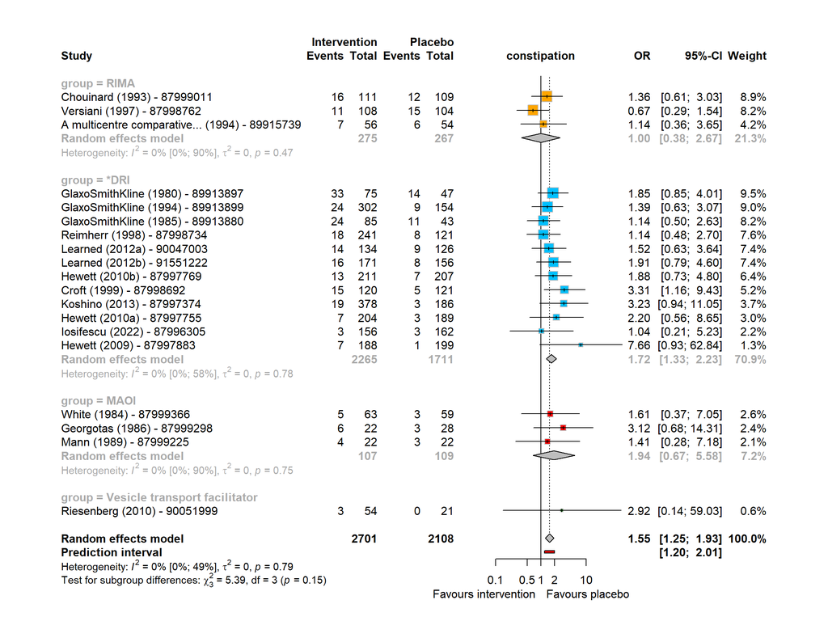

There were no significant subgroup differences between participants assigned to different classes of drug.

#### Sub-group and meta-regression analyses

We found enough data (i.e. at least ten studies) to conduct a meta-regression for age, proportion of females, and treatment duration. Insufficient data existed for anhedonia baseline score, anxiety baseline score, and reward baseline score.

- The meta-regression for age was not significant.
- The meta-regression for proportion of females was not significant.
- The meta-regression for treatment duration was not significant.

### Secondary outcome: dizziness

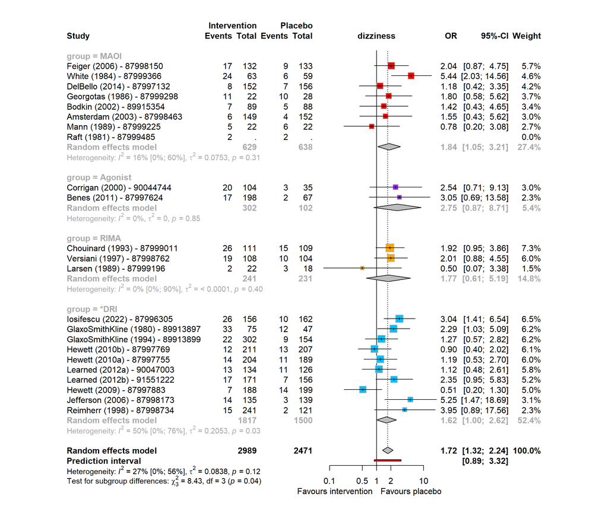

**Figure X** Forest plot for dizziness for the comparison of pro-dopaminergic interventions vs placebo at 8 (4-12) weeks. OR: odds ratio, 95%CI: 95% confidence intervals.

#### Sub-group and meta-regression analyses

We found enough data (i.e. at least ten studies) to conduct a meta-regression for age and proportion of females. Insufficient data existed for anhedonia baseline score, anxiety baseline score, reward baseline score, and treatment duration.

- The meta-regression for age was not significant.
- The meta-regression for proportion of females was not significant.

### Secondary outcome: dry mouth

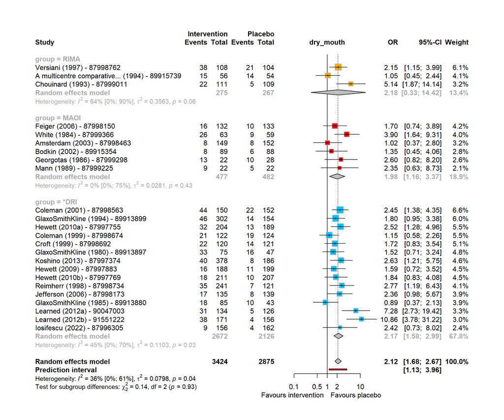

**Figure X** Forest plot for dry mouth for the comparison of pro-dopaminergic interventions vs placebo at 4-12 weeks. OR: odds ratio, 95%CI: 95% confidence intervals.

#### Sub-group and meta-regression analyses

We found enough data (i.e. at least ten studies) to conduct a meta-regression for age, proportion of females, and treatment duration. Insufficient data existed for anhedonia baseline score, anxiety baseline score, and reward baseline score.

- The meta-regression for age was not significant.
- The meta-regression for proportion of females was significant (beta = -2.071, 95% CI from -3.834 to -0.308).
- The meta-regression for treatment duration was not significant.

### Secondary outcome: vomiting

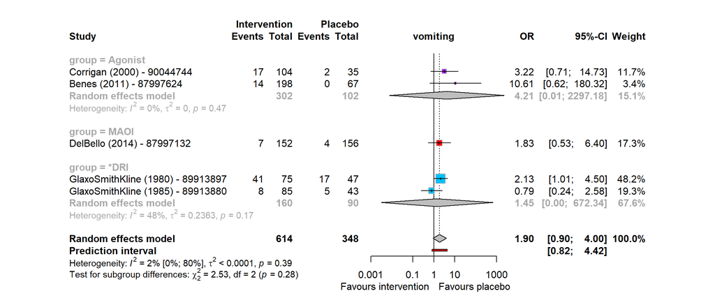

**Figure X** Forest plot for vomiting for the comparison of pro-dopaminergic interventions vs placebo at 4-12 weeks. OR: odds ratio, 95%CI: 95% confidence intervals.

#### Sub-group and meta-regression analyses

We did not find sufficient data (i.e. at least ten studies) to conduct a meta-regression for the investigated predictors. Insufficient data existed for age, proportion of females, anhedonia baseline score, anxiety baseline score, reward baseline score, and treatment duration.

## Summary of evidence tables

[output not shown]